# **Assignment 1**

#### **Author: Tejas Patil**

#### **Date: 04/05/2020**

#### **Executive Summary**:

##### **Problem Statement:**

##### Disease dataset provides the information of people and their physical and habitual attributes that can be helpful in predicting if that person will suffer from a particular type of disease or not. The aim of this project is to build the data analytical models that will help in predicting a person as disease prone or disease safe.

##### **1. Data Load and Cleanup:**

##### This section deals with cleaning the data. We’ll check the data for missing values, outliers etc. and treat those observations with suitable values. The data will also be checked for presence of any duplicate values. It also includes the statistically analysing the data.

##### **2. EDA and Feature selection:**

##### This section involves a deeper understanding of the data using tabular and visual representation of the data and **creating new columns** (tranforming data into a useful form). We’ll use **logistic regression** for the feature selection. Note that we are using logistic regression here because this a binary classification problem and logistic regression can provide good variable importance.

##### **3.Model building and evaluation:**

##### In this section, we will buil 6 different classification models namely: K-Nearest neighbors, Naive Bayes classifier, Random Forest, Supply vector machine linear and non linear, and finally Gradient boosting machine model. Models will be evaluated based on suitable evaluation parameters **(Accuracy and Recall)**. At last, we will use these models for predictions on test dataset.

### **1. Data load and Cleanup**

##### Importing the necessary libraries

```r
library(ggplot2)
library(gridExtra)
library(caret)
library(mlbench)
library(MLmetrics)
library(fastDummies)
library(data.table)
library(corrplot)
library(pROC)
library(klaR)
library(kernlab)
library(gbm)
#install.packages('e1071', dependencies=TRUE)
library(e1071)

setwd('C:/Users/hp/Desktop/IST 707/Assignments/Assignment 3')
#getwd()
```

##### Importing the csv file into R enviornment and checking the structure and statistical summary of the dataset

##### Some early observations from the data:

##### AGE: minimum age is 29 years and maximum is 64 years. Hence our population for this problem is mainly adult people and people in early stages of old age

##### GENDER: training data is pretty imbalanced with respect to the gender variable. Females are almost twice that of male population.

##### Smoke, Alcohol and Excercise are classified as 1 and 0. The variable importance of these variables is doubtful as some people might be doing one of these things in small/large quantity relative to the other quantity.

```r
train_df <- read.csv('Disease Prediction Training.csv', stringsAsFactors = F)
#summary(train_df)
#str(train_df)
```

##### Checked the data for Missing values. The results returned shows us that there are **no missing values** in the data

```r
apply(is.na(train_df),2,sum)
```

```
##                 Age              Gender              Height
##                   0                   0                   0
##              Weight High.Blood.Pressure  Low.Blood.Pressure
##                   0                   0                   0
##         Cholesterol             Glucose               Smoke
##                   0                   0                   0
##             Alcohol            Exercise             Disease
##                   0                   0                   0
```

##### Checked the data for duplicate observations. The results returned shows us that there were **1752 duplicate observations** in the data. So, we have selected only the unique values

```r
nrow(train_df) - nrow(unique(train_df))
```

```
## [1] 1752
```

```r
train_un <- unique(train_df)
```

### **2. Exploratory Data Analysis**

#### **Analysing the target variable**

##### We find that target variable is of binary type and has 2 levels in it. So, this will be a binary classification problem. Here most important observation is that our target variable is balanced

```r
str(train_un$Disease)
```

```
##  int [1:47248] 0 1 0 0 0 0 1 0 1 0 ...
```

```r
table(train_un$Disease)
```

```
##
##     0     1
## 23172 24076
```

##### For the further EDA, we create 2 new dataframes containing only categorical and only numerical attributes respectively. Before that we convert all binary integer variables to factor for the easying the analysis process

```r
train_un$Smoke <- as.factor(train_un$Smoke)
train_un$Alcohol <- as.factor(train_un$Alcohol)
train_un$Exercise <- as.factor(train_un$Exercise)
train_un$Disease <- as.factor(train_un$Disease)


cat_df <- train_un[sapply(train_un, is.character) | sapply(train_un, is.factor)]
num_df <- train_un[sapply(train_un, is.numeric) | sapply(train_un, is.integer)]
```

##### Creating a function to generate bar plot for all the categorical variables and then using the grid plot to display all the visualization.

##### Impotant observations here are that most of the people do not smoke or drink and do excercise regularly. Ideally, the disease variable should have more ’0’s than ’1’s which questions the variable impotance for these three variables.

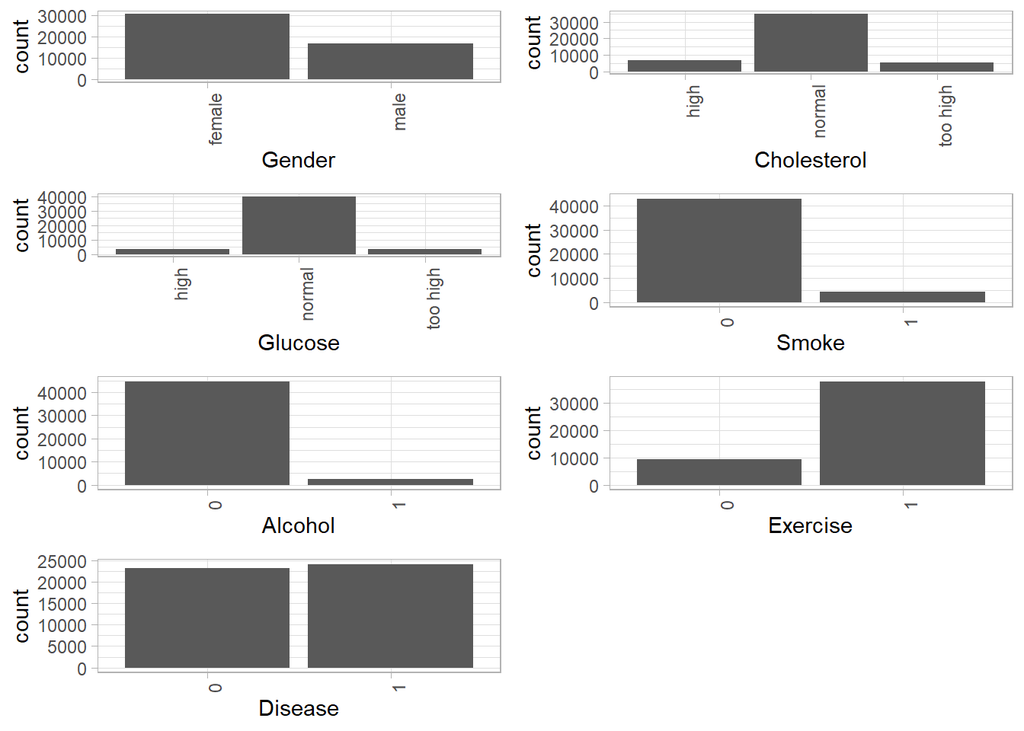

```r
bar_plot <- function(data_in, i) {
  data <- data.frame(x=data_in[[i]])
  p <- ggplot(data=data, aes(x=factor(x))) + stat_count() + xlab(colnames(data_in)[i]) + theme_light() +
    theme(axis.text.x = element_text(angle = 90, hjust =1))
  return (p)
}
mygrid1 <- list()
for (i in 1:length(cat_df)){
  myplot1 <- bar_plot(cat_df, i)
  mygrid1 <- c(mygrid1, list(myplot1))
}
do.call("grid.arrange", c(mygrid1, ncol=2))
```

##### Again creating a function, this time to generate a grid plot for displaying boxplots for all the numerical variables. We see that there are considerable **outliers** in variables named ‘Height’, ‘Weight’, ‘High.Blood.Pressure’ and ‘Low.Blood.Pressure’.

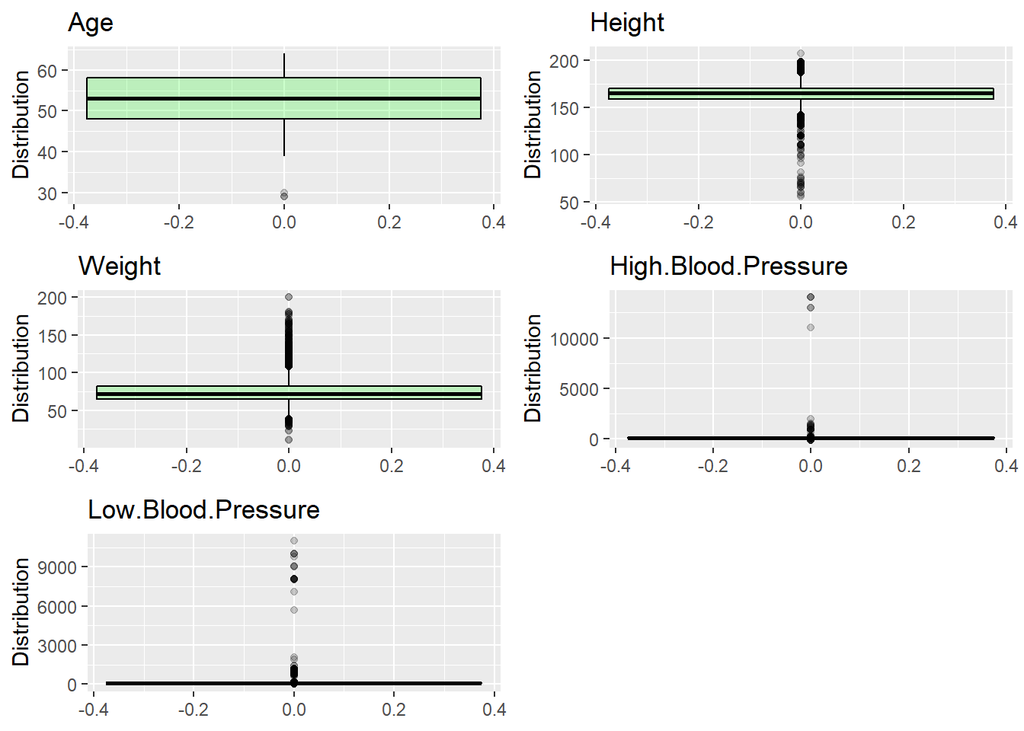

```r
box_plot <- function(data_in, i) {
  p <- ggplot(data_in, aes(y = data_in[,i])) + geom_boxplot(color="black", fill="green", alpha=0.2) + ggtitle(colnames(data_in)[i]) + ylab("Distribution") + theme(legend.position="none")
  return (p)
}

mygrid2 <- list()
for (i in 1:length(num_df)){
  myplot2 <- box_plot(num_df, i)
  mygrid2 <- c(mygrid2, list(myplot2))
}
do.call("grid.arrange", c(mygrid2, ncol=2))
```

##### Now let us check the range of these outliters. We create a new dataframe and check the values for extreme percentile values from both the ends for variables containing outliers

```r
quantiles <- c(0.0, 0.001, 0.002, 0.003, 0.01, 0.985, 0.99, 0.997, 0.998, 0.999, 1)
out_df <- data.frame(row.names = quantiles)
for (i in 1:length(num_df)){
  q <- as.vector(quantile(num_df[,i], quantiles))
  out_df[,i] <- q
}
colnames(out_df) <- colnames(num_df)
out_df <- t(out_df) #taking the transpose
print(out_df)
```

```
##                        0   0.001 0.002 0.003 0.01 0.985 0.99 0.997 0.998
## Age                   29  39.000    39    39   39    64   64    64    64
## Height                55 120.000   137   140  147   182  184   187   189
## Weight                10  40.000    41    43   48   113  117   130   135
## High.Blood.Pressure -150  12.000    13    70   90   180  180   200   200
## Low.Blood.Pressure     0  41.235    53    60   60   130 1000  1100  1100
##                     0.999     1
## Age                    64    64
## Height                190   207
## Weight                150   200
## High.Blood.Pressure   220 14020
## Low.Blood.Pressure   1110 11000
```

##### Creating a function to treat outliers by winsorizing to specific boundaries and using it to treat all numerical variables (except age) to treat outliers

```r
Out_Treat_W = function(x, lb, ub){
  LC = quantile(x, lb)
  UC = quantile(x, ub)
  UOut <- which(x > UC)
  LOut <- which(x < LC)
  for (i in 1:length(UOut)){
    x[UOut[i]] <- UC
  }
  for (i in 1:length(LOut)){
    x[LOut[i]] <- LC
  }
  return(x)
}
train_un$Height <- Out_Treat_W(train_un$Height, 0.001, 1)
train_un$Weight <- Out_Treat_W(train_un$Weight, 0.001, 1)
train_un$Low.Blood.Pressure <- Out_Treat_W(train_un$Low.Blood.Pressure, 0.001, 0.985)
train_un$High.Blood.Pressure <- Out_Treat_W(train_un$High.Blood.Pressure, 0.003, 0.999)
```

##### Updating the num_data with winsorized numerical variable. Creating a function to generate Histogram for numerical variables. Implementing that function on every variable in num_df dataset. We observe that all the distribution are slightly skewed but more or less normally distributed.

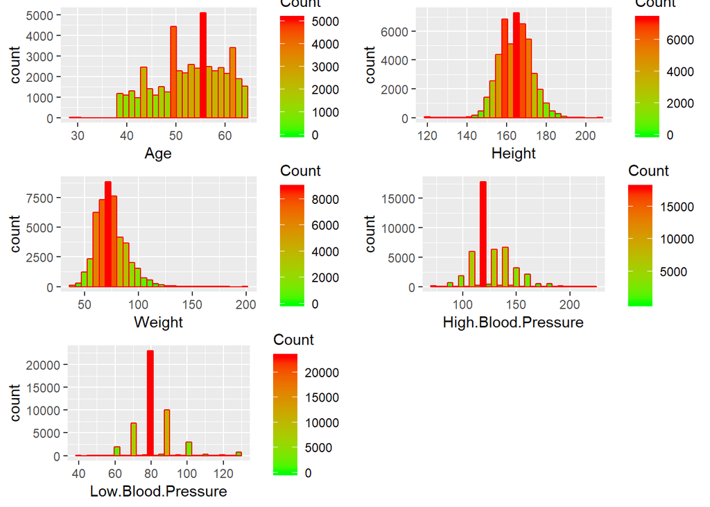

```r
num_df <- train_un[sapply(train_un, is.numeric) | sapply(train_un, is.integer)]

hist_plot <- function(data_in, i) {
  data <- data.frame(x=data_in[[i]])
  p <- ggplot(data=data, aes(data[,1])) +
    geom_histogram(bins = 30, col="red", aes(fill=..count..)) +
    xlab(colnames(data_in)[i]) +
    scale_fill_gradient("Count", low="green", high="red")
  return (p)
}
mygrid2 <- list()
for (i in 1:length(num_df)){
  myplot2 <- hist_plot(num_df, i)
  mygrid2 <- c(mygrid2, list(myplot2))
}
do.call("grid.arrange", c(mygrid2, ncol=2))
```

##### Plotting the correlation matrix to check for the multicollinearity between numeric independent variables. Only significant correlation is between **Low blood pressure** and **High blod pressure** variables.

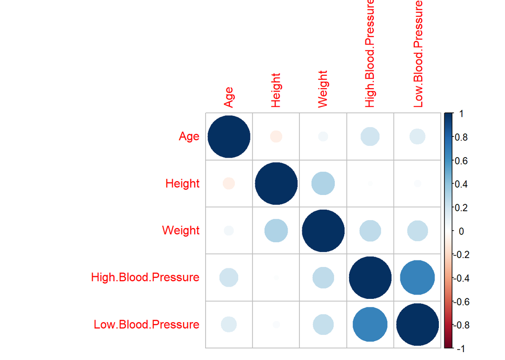

```r
corMatrix <- cor(num_df)
#View(descrCor)
#print(descrCor)
corrplot(corMatrix)
```

#### Creating new variables:

##### We have two variables that measure the blood pressure (High and Low). Now, we will create a single categorical variable that will try to capture the combined effect of both variables on a person’s health. We will the classifiy the health and unhealthy blood pressure ranges into 5 different categories namely: **Normal**, **Elevated** (Slight increase), **Hypertension (Stage 1)**, **Hypertension (Stage 2)** and **Hypertensive Crisis** (Critical condition). These ranges are obtained using the domain knowledge from the website:

##### [https://www.heart.org/en/health-topics/high-blood-pressure/understanding-blood-pressure-readings]

##### Checking if the variable can make a impact on our model

```r
for (i in 1:nrow(train_un)) {
  if (train_un$High.Blood.Pressure[i] >= 180 | train_un$Low.Blood.Pressure[i] >= 120) {
    train_un$BP_Category[i] = "Hypertensive"
  }
  else if (train_un$High.Blood.Pressure[i] >= 140 | train_un$Low.Blood.Pressure[i] >= 90) {
    train_un$BP_Category[i] = "HT_stage2"
  }
  else if (train_un$High.Blood.Pressure[i] >= 130 | train_un$Low.Blood.Pressure[i] >= 80) {
    train_un$BP_Category[i] = "HT_stage1"
  }
  else if (train_un$High.Blood.Pressure[i] >= 120 & train_un$Low.Blood.Pressure[i] < 80) {
    train_un$BP_Category[i] = "Elevated"
  }
  else {
    train_un$BP_Category[i] = "Normal"
  }
}
train_un$BP_Category <- as.factor(train_un$BP_Category)
table(train_un$Disease, train_un$BP_Category)
```

```
##
##     Elevated HT_stage1 HT_stage2 Hypertensive Normal
##   0     1431     12790      3516          237   5198
##   1      714      8406     12308         1199   1449
```

##### Now we’ll be creating two more new variable called BMI (Body Mass Index). BMI is a measure of body fat considering height and weight of a person, it applies to adult men and women. The second variable is nothing but the categorization of the BMI variable.

```r
for (i in 1:nrow(train_un)) {
  train_un$BMI[i] <- (train_un$Weight[i] / ((train_un$Height[i]/100)**2))
  if (train_un$BMI[i] <= 18) {
    train_un$BMI_CAT[i] = "Underweight"
  }
  else if (train_un$BMI[i] <= 24) {
    train_un$BMI_CAT[i] = "Healthy"
  }
  else if (train_un$BMI[i] <= 29) {
    train_un$BMI_CAT[i] = "Overweight"
  }
  else {
   train_un$BMI_CAT[i] = "Obese"
  }
}
train_un$BMI_CAT <- as.factor(train_un$BMI_CAT)
```

##### Of all the models we’ll be using, few are distance based algorithms. Hence, it is very necessary to scale the numerical variables in our data. We have tried here 2 types of scaling: **normalization and standardization**. After running the models for both the scaling, standard scale was finally chosen for the data.

```r
train_sc <- train_un

for(i in 1:length(colnames(train_sc))){
  if(class(train_sc[,i]) == "numeric" || class(train_sc[,i]) == "integer"){
    train_sc[,i] <- as.vector(scale(train_sc[,i]))
  }
}

##the normalization function is created
#norm_ZN <- function(x){
#  y <- c()
#  for (i in 1:length(x)){
#    y <- c(y, ((x[i]) - min(x))/(max(x) - min(x)))
#  }
#  return(y)
#}
#for(i in 1:length(train_sc)){
#  if(class(train_sc[,i]) == "numeric" || class(train_sc[,i]) == "integer"){
#    train_sc[,i] <- norm_ZN(train_sc[,i])
#  }
#}
```

##### Now, we’ll be creating the **dummy variables** for all the categorical variables our data. After we are done with that we need to drop the original categorical variables.

```r
dummies <- c('Gender','Cholesterol','Glucose', 'BP_Category', 'BMI_CAT')
train_dm <- dummy_cols(train_sc, select_columns = dummies) # it will convert your data to hot encoding
train_dm <- train_dm[,-which(names(train_dm) %in% dummies)]
#str(train_dm)
#View(train_dm)
```

##### The newly created dummy variables are all of ‘factor’ data type. We need to convert them to ‘integer’ data type. But we will keep our traget variable as a factor data type only.

```r
i <- sapply(train_dm, is.factor)
train_dm[i] <- lapply(train_dm[i], as.integer)

train_dm$Disease <- as.factor(train_dm$Disease)
train_dm_saved <- train_dm
```

##### Since this is a binary classification problem, we can use **logistic regression** model to check the importance of the variables. This will give us confidence in our newly created variables and eliminate the variables that are not significant.

```r
summary(glm(Disease ~. , data=train_dm, family=binomial))
```

```
##
## Call:
## glm(formula = Disease ~ ., family = binomial, data = train_dm)
##
## Deviance Residuals:
##     Min       1Q   Median       3Q      Max
## -3.4150  -0.8978   0.3106   0.8726   2.4388
##
## Coefficients: (5 not defined because of singularities)
##                          Estimate Std. Error z value Pr(>|z|)
## (Intercept)               0.97012    0.18089   5.363 8.18e-08 ***
## Age                       0.35493    0.01113  31.879  < 2e-16 ***
## Height                    0.02253    0.04954   0.455 0.649188
## Weight                    0.06988    0.09207   0.759 0.447841
## High.Blood.Pressure       0.61697    0.02147  28.738  < 2e-16 ***
## Low.Blood.Pressure        0.04708    0.02499   1.884 0.059513 .
## Smoke                    -0.15403    0.04145  -3.716 0.000203 ***
## Alcohol                  -0.20829    0.04999  -4.167 3.09e-05 ***
## Exercise                 -0.20401    0.02642  -7.722 1.15e-14 ***
## BMI                       0.07089    0.08663   0.818 0.413180
## Gender_female             0.03405    0.02691   1.265 0.205798
## Gender_male                    NA         NA      NA       NA
## Cholesterol_normal       -1.05398    0.04271 -24.676  < 2e-16 ***
## Cholesterol_high         -0.68233    0.05015 -13.605  < 2e-16 ***
## `Cholesterol_too high`         NA         NA      NA       NA
## Glucose_normal            0.32078    0.04711   6.809 9.84e-12 ***
## Glucose_high              0.31353    0.06105   5.135 2.82e-07 ***
## `Glucose_too high`             NA         NA      NA       NA
## BP_Category_Elevated     -0.04217    0.05886  -0.716 0.473694
## BP_Category_HT_stage1     0.10166    0.04691   2.167 0.030223 *
## BP_Category_HT_stage2     0.91849    0.07376  12.452  < 2e-16 ***
## BP_Category_Hypertensive  0.51599    0.15853   3.255 0.001134 **
## BP_Category_Normal             NA         NA      NA       NA
## BMI_CAT_Healthy           0.02390    0.14420   0.166 0.868340
## BMI_CAT_Obese             0.06558    0.15840   0.414 0.678891
## BMI_CAT_Overweight        0.11940    0.14747   0.810 0.418156
## BMI_CAT_Underweight            NA         NA      NA       NA
## ---
## Signif. codes:  0 '***' 0.001 '**' 0.01 '*' 0.05 '.' 0.1 ' ' 1
##
## (Dispersion parameter for binomial family taken to be 1)
##
##     Null deviance: 65482  on 47247  degrees of freedom
## Residual deviance: 52467  on 47226  degrees of freedom
## AIC: 52511
##
## Number of Fisher Scoring iterations: 4
```

```r
lr_drop <- c('Height', 'Weight', 'BMI_CAT_Healthy', 'BMI_CAT_Obese', 'BMI_CAT_Overweight', 'BMI_CAT_Underweight')
train_dm <- train_dm[,-which(names(train_dm) %in% lr_drop)]

for (i in 1:nrow(train_dm)) {
  if (train_dm$BP_Category_Elevated[i] == "1") {
    train_dm$BP_Category_Normal[i] = "1"
  }
  else {
    train_dm$BP_Category_Normal[i] = train_dm$BP_Category_Normal[i]
  }
}
train_dm$BP_Category_Normal <- as.integer(train_dm$BP_Category_Normal)
train_dm$BP_Category_Elevated <- NULL
#str(train_dm)
```

##### Splitting the traing data into two parts, training and validation datasets. Here we are using **75-25** split.

```r
set.seed(73)
train_index <- createDataPartition(train_dm$Disease, p = 0.75, list = FALSE)

train_dm_train <- train_dm[train_index, ]
train_dm_validate <- train_dm[-train_index, ]
```

### **3. Model building and Evaluation**

### **a] K - Nearest Neighbors**

##### First Applying the base model (without any hyperparameters) to the training dataset

```r
#knn_base <- train(Disease ~ ., data = train_dm_train, method = "knn")
print(knn_base)
```

```
## k-Nearest Neighbors
##
## 35436 samples
##    19 predictor
##     2 classes: '1', '2'
##
## No pre-processing
## Resampling: Bootstrapped (25 reps)
## Summary of sample sizes: 35436, 35436, 35436, 35436, 35436, 35436, ...
## Resampling results across tuning parameters:
##
##   k  Accuracy   Kappa
##   5  0.6675902  0.3349017
##   7  0.6817606  0.3632957
##   9  0.6910581  0.3819452
##
## Accuracy was used to select the optimal model using the largest value.
## The final value used for the model was k = 9.
```

##### Plotting the graph for accuracy of the model vs the number of neighbors selected in a model. It shows that there a linear increase in accuracy with increase in K value.

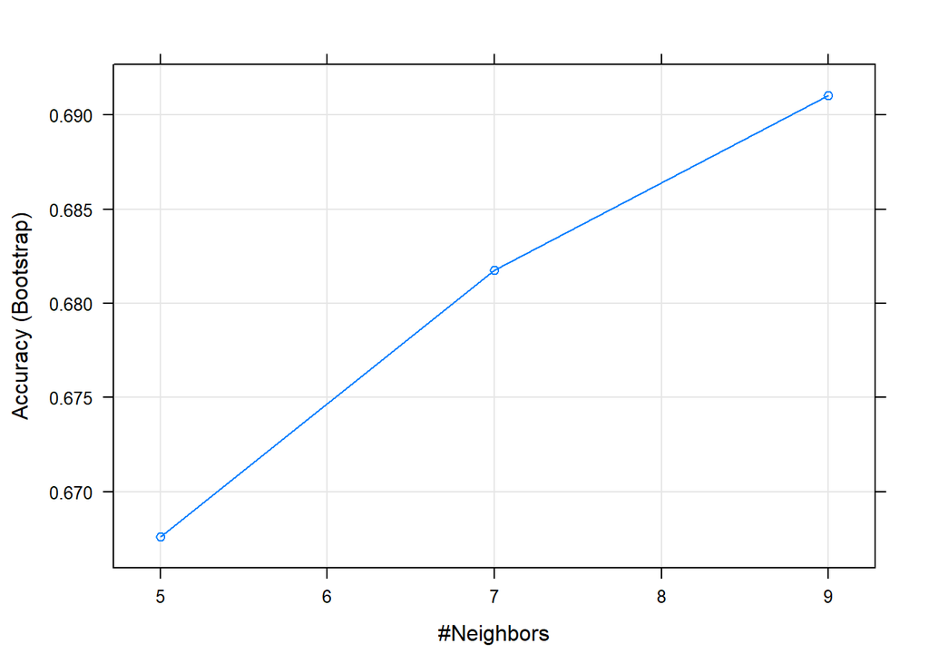

```r
plot(knn_base)
```

##### Plotting the confusion matrix to evaluate model performance on validation dataset by analysing the evaluation parameters such as accuracy, recall, specificity etc. Looking at the p-value we are more than **99% confident** that our accuracy is more than a random model (No Information rate).

```r
knn_base_predict <- predict(knn_base, newdata = train_dm_validate)
confusionMatrix(knn_base_predict, train_dm_validate$Disease)
```

```
## Confusion Matrix and Statistics
##
##           Reference
## Prediction    1    2
##          1 4181 1827
##          2 1612 4192
##
##                Accuracy : 0.7089
##                  95% CI : (0.7006, 0.717)
##     No Information Rate : 0.5096
##     P-Value [Acc > NIR] : < 2.2e-16
##
##                   Kappa : 0.4179
##
##  Mcnemar's Test P-Value : 0.0002631
##
##             Sensitivity : 0.7217
##             Specificity : 0.6965
##          Pos Pred Value : 0.6959
##          Neg Pred Value : 0.7223
##              Prevalence : 0.4904
##          Detection Rate : 0.3540
##    Detection Prevalence : 0.5086
##       Balanced Accuracy : 0.7091
##
##        'Positive' Class : 1
##
```

```r
#set.seed(73)
#knn_acc <- train(Disease ~ ., data = train_dm_train, method = "knn",
#                    tuneGrid = data.frame(k = seq(30, 40)),
#                    trControl = trainControl(method = "repeatedcv",
#                                             number = 3, repeats = 3))
print(knn_acc)
```

```
## k-Nearest Neighbors
##
## 35436 samples
##    19 predictor
##     2 classes: '1', '2'
##
## No pre-processing
## Resampling: Cross-Validated (3 fold, repeated 3 times)
## Summary of sample sizes: 23624, 23624, 23624, 23624, 23624, 23624, ...
## Resampling results across tuning parameters:
##
##   k   Accuracy   Kappa
##   30  0.7272171  0.4548453
##   31  0.7276781  0.4557803
##   32  0.7278380  0.4560953
##   33  0.7278850  0.4562055
##   34  0.7281766  0.4567896
##   35  0.7285999  0.4576445
##   36  0.7287034  0.4578605
##   37  0.7285905  0.4576455
##   38  0.7282613  0.4569869
##   39  0.7284400  0.4573628
##   40  0.7288727  0.4582456
##
## Accuracy was used to select the optimal model using the largest value.
## The final value used for the model was k = 40.
```

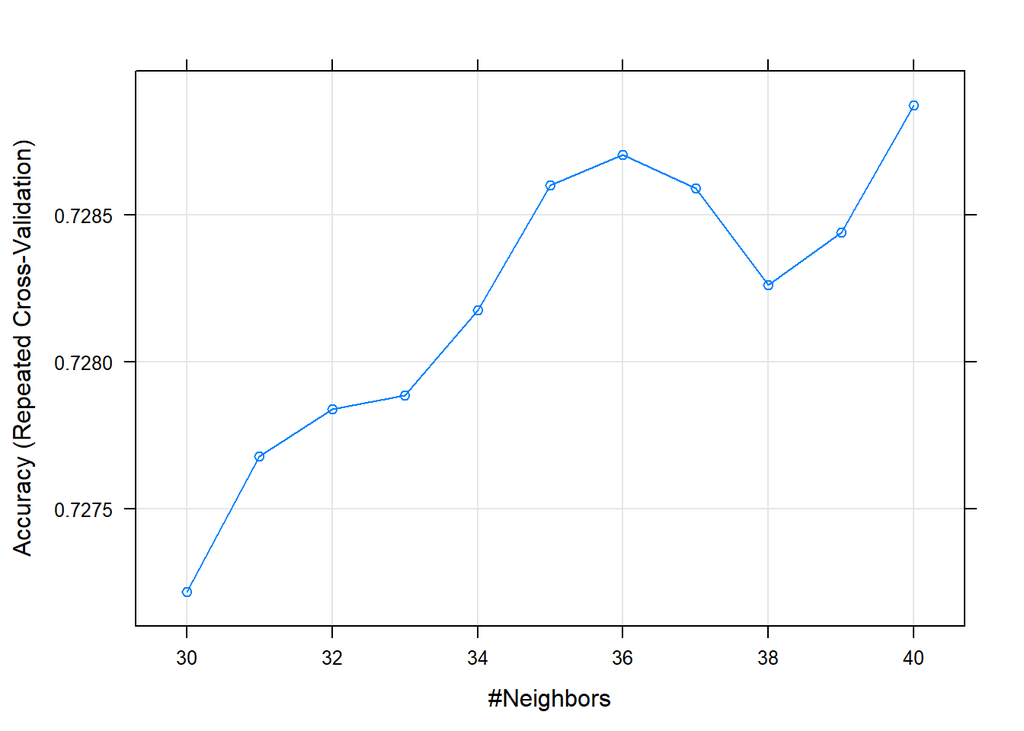

```r
plot(knn_acc)
```

##### Plotting the confusion matrix to evaluate model performance on validation dataset by analysing the evaluation parameters such as accuracy, recall, specificity etc. Important point to note: Very small difference between training and validation accuracy: So there is no overfitting, also there is remarkable **increase in Recall**

```r
knn_acc_predict <- predict(knn_acc, newdata = train_dm_validate)
confusionMatrix(knn_acc_predict, train_dm_validate$Disease)
```

```
## Confusion Matrix and Statistics
##
##           Reference
## Prediction    1    2
##          1 4357 1863
##          2 1436 4156
##
##                Accuracy : 0.7207
##                  95% CI : (0.7125, 0.7288)
##     No Information Rate : 0.5096
##     P-Value [Acc > NIR] : < 2e-16
##
##                   Kappa : 0.442
##
##  Mcnemar's Test P-Value : 1.2e-13
##
##             Sensitivity : 0.7521
##             Specificity : 0.6905
##          Pos Pred Value : 0.7005
##          Neg Pred Value : 0.7432
##              Prevalence : 0.4904
##          Detection Rate : 0.3689
##    Detection Prevalence : 0.5266
##       Balanced Accuracy : 0.7213
##
##        'Positive' Class : 1
##
```

##### Now, fine tuning the model using hyperparameters and using cross validation and running the model for **‘recall’**. The reason for running the model for recall is that in this problem we want to reduce the **type 2 error** i.e. we’ll have to reduce the false negative values, hence increase the recall.

```r
#knn_sens <- train(make.names(Disease) ~ ., data = train_dm_train, method = "knn",
#                    tuneGrid = data.frame(k = seq(30, 40)),
#                    trControl = trainControl(method = "repeatedcv",
#                                             number = 3, repeats = 3, classProbs = TRUE,    #summaryFunction = prSummary), metric="Recall")
print(knn_sens)
```

```
## k-Nearest Neighbors
##
## 35436 samples
##    19 predictor
##     2 classes: 'X1', 'X2'
##
## No pre-processing
## Resampling: Cross-Validated (3 fold, repeated 3 times)
## Summary of sample sizes: 23624, 23624, 23624, 23624, 23624, 23624, ...
## Resampling results across tuning parameters:
##
##   k   AUC        Precision  Recall     F
##   30  0.7615553  0.7094188  0.7522489  0.7301993
##   31  0.7622339  0.7092807  0.7540326  0.7309659
##   32  0.7627886  0.7093564  0.7543012  0.7311335
##   33  0.7642038  0.7091533  0.7545313  0.7311318
##   34  0.7651301  0.7092105  0.7555862  0.7316580
##   35  0.7657593  0.7094843  0.7564110  0.7321887
##   36  0.7662414  0.7094304  0.7561233  0.7320269
##   37  0.7668504  0.7097697  0.7570823  0.7326560
##   38  0.7673975  0.7093095  0.7564302  0.7321045
##   39  0.7683502  0.7094777  0.7576002  0.7327422
##   40  0.7688184  0.7089058  0.7581756  0.7327050
##
## Recall was used to select the optimal model using the largest value.
## The final value used for the model was k = 40.
```

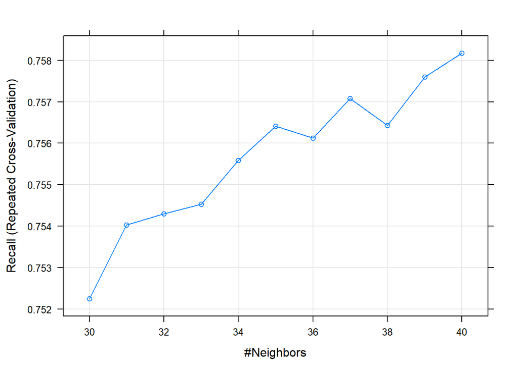

```r
plot(knn_sens)
```

##### Plotting the confusion matrix to evaluate model performance on validation dataset by analysing the evaluation parameters such as accuracy, recall, specificity etc.

```r
knn_sens_pred <- predict(knn_sens, newdata = train_dm_validate)
confusionMatrix(knn_sens_pred, as.factor(make.names(train_dm_validate$Disease)))
```

```
## Confusion Matrix and Statistics
##
##           Reference
## Prediction   X1   X2
##         X1 4356 1857
##         X2 1437 4162
##
##                Accuracy : 0.7211
##                  95% CI : (0.7129, 0.7292)
##     No Information Rate : 0.5096
##     P-Value [Acc > NIR] : < 2.2e-16
##
##                   Kappa : 0.4428
##
##  Mcnemar's Test P-Value : 2.867e-13
##
##             Sensitivity : 0.7519
##             Specificity : 0.6915
##          Pos Pred Value : 0.7011
##          Neg Pred Value : 0.7433
##              Prevalence : 0.4904
##          Detection Rate : 0.3688
##    Detection Prevalence : 0.5260
##       Balanced Accuracy : 0.7217
##
##        'Positive' Class : X1
##
```

##### Creating a function to plot the Receiver Operating Characteristics curve. Using sensitivity (recall) on y-axis and (1 - specificity) on x-axis we plot this curve. Values are obtained by keeping probability for every point as a threshold.

```r
ROC_AUC <- function(x){
  roc_prob_pred <- predict(x, newdata = train_dm_validate, type = 'prob')
  roc_curve=roc(response=train_dm_validate$Disease, predictor= roc_prob_pred$`1`)
  fig <- plot(roc_curve, col="red", lwd=3, main="ROC curve")
  score <- auc(roc_curve)
  ro_au <- list(fig, score)
  return(ro_au)
}
```

##### Plotting the ROC curve for predicted classes of an observation and Calculating he area under that curve (AUC)

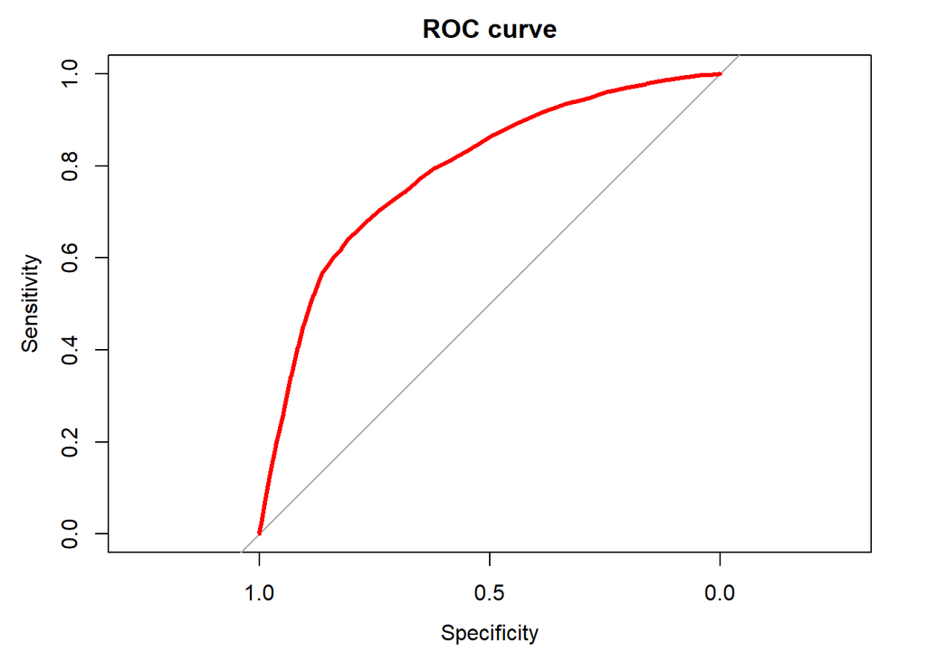

```
## [[1]]
##
## Call:
## roc.default(response = train_dm_validate$Disease, predictor = roc_prob_pred$`1`)
##
## Data: roc_prob_pred$`1` in 5793 controls (train_dm_validate$Disease 1) > 6019 cases (train_dm_validate$Disease 2).
## Area under the curve: 0.7872
##
## [[2]]
## Area under the curve: 0.7872
```

```r
ROC_AUC(knn_acc)
```

### **b] Naive-Bayes Classifier**

##### **Naive-Bayes Classifier Base Model**

##### Running the naive bayes base model on training dataset. Naive Bayes provided in “caret” package and “klaR” was giving error for this dataset. So using the “naiveBayes” from **“e1071”** library

##### This model used **bayes theorem** to predict the probability of an observation belonging to a class based on a **naive assumption** that all the ‘X’ variables in data are independent of each other. It combines the prior knowledge **[P(Y)]** with evidence **[P(X)]** with the help of likelihood probability **[p(Y|X)]**

##### Naive Bayes model is giving very high recall for the model. Accuracy stays in close range of KNN.

```r
#nb_base <- naiveBayes(Disease ~ ., data = train_dm_train)
print(nb_base)
```

```
##
## Naive Bayes Classifier for Discrete Predictors
##
## Call:
## naiveBayes.default(x = X, y = Y, laplace = laplace)
##
## A-priori probabilities:
## Y
##         1         2
## 0.4904335 0.5095665
##
## Conditional probabilities:
##    Age
## Y         [,1]      [,2]
##   1 -0.2420540 1.0081956
##   2  0.2360336 0.9296437
##
##    High.Blood.Pressure
## Y        [,1]      [,2]
##   1 -0.428439 0.7583832
##   2  0.417525 1.0283864
##
##    Low.Blood.Pressure
## Y         [,1]      [,2]
##   1 -0.3344094 0.8213829
##   2  0.3264909 1.0502216
##
##    Smoke
## Y       [,1]      [,2]
##   1 1.099776 0.2997092
##   2 1.085729 0.2799705
##
##    Alcohol
## Y       [,1]      [,2]
##   1 1.058461 0.2346205
##   2 1.053940 0.2259061
##
##    Exercise
## Y       [,1]      [,2]
##   1 1.811497 0.3911249
```

[output cut: 51 more lines]

```
##
##    BP_Category_HT_stage2
## Y        [,1]      [,2]
##   1 0.1521376 0.3591646
##   2 0.5132636 0.4998379
##
##    BP_Category_Hypertensive
## Y          [,1]       [,2]
##   1 0.009897002 0.09899301
##   2 0.050285208 0.21853890
##
##    BP_Category_Normal
## Y        [,1]      [,2]
##   1 0.2871281 0.4524349
##   2 0.0897159 0.2857822
```

```r
summary(nb_base)
```

```
##           Length Class  Mode
## apriori    2     table  numeric
## tables    19     -none- list
## levels     2     -none- character
## isnumeric 19     -none- logical
## call       4     -none- call
```

##### Plotting the confusion matrix to evaluate model performance on validation dataset by analysing the evaluation parameters such as accuracy, recall, specificity etc.

```r
nb_base_predict <- predict(nb_base, train_dm_validate)
confusionMatrix(nb_base_predict, train_dm_validate$Disease)
```

```
## Confusion Matrix and Statistics
##
##           Reference
## Prediction    1    2
##          1 4549 2143
##          2 1244 3876
##
##                Accuracy : 0.7133
##                  95% CI : (0.705, 0.7214)
##     No Information Rate : 0.5096
##     P-Value [Acc > NIR] : < 2.2e-16
##
##                   Kappa : 0.428
##
##  Mcnemar's Test P-Value : < 2.2e-16
##
##             Sensitivity : 0.7853
##             Specificity : 0.6440
##          Pos Pred Value : 0.6798
##          Neg Pred Value : 0.7570
##              Prevalence : 0.4904
##          Detection Rate : 0.3851
##    Detection Prevalence : 0.5665
##       Balanced Accuracy : 0.7146
##
##        'Positive' Class : 1
##
```

### **Naive Bayes Classifier Tuned**

##### Naive bayes classifier calculates product of probabilities of features for a class. If the data dosen’t have enough values, we might face a problem of combination of X variables which never occured for a class. This will give zero probability and this 0 will run through all the features to make probability for a class = 0. Hence, we add a **laplace smoother**, it adds a small non zero number to the numerator which ensures non zero probability for any class.

```r
#nb_models <- list()
#for  (i in 1:5){
#  nb_tuned <- naiveBayes(Disease ~ ., data = train_dm_train, laplace = i)
#  lap_par <- toString(i)
#   nb_models[[lap_par]] <- nb_tuned
#}
#Accuracies <- c()
#for (i in 1:length(nb_models)){
#  nb_find_best <- predict(nb_models[[i]], train_dm_validate)
#  cm_nb <- confusionMatrix(nb_find_best, train_dm_validate$Disease)
#  Accuracies <- c(Accuracies, cm_nb$overall["Accuracy"])
#}
#nb_tuned_best <- nb_models[[which.max(Accuracies)]]
```

##### Now, predicting the values for validation dataset. Then using the predictions to plot confusion matrix. Evaluating the parameters such as accuracy and recall.

```r
nb_tuned_best_predict <- predict(nb_tuned_best, train_dm_validate)
confusionMatrix(nb_tuned_best_predict, train_dm_validate$Disease)
```

```
## Confusion Matrix and Statistics
##
##           Reference
## Prediction    1    2
##          1 4549 2143
##          2 1244 3876
##
##                Accuracy : 0.7133
##                  95% CI : (0.705, 0.7214)
##     No Information Rate : 0.5096
##     P-Value [Acc > NIR] : < 2.2e-16
##
##                   Kappa : 0.428
##
##  Mcnemar's Test P-Value : < 2.2e-16
##
##             Sensitivity : 0.7853
##             Specificity : 0.6440
##          Pos Pred Value : 0.6798
##          Neg Pred Value : 0.7570
##              Prevalence : 0.4904
##          Detection Rate : 0.3851
##    Detection Prevalence : 0.5665
##       Balanced Accuracy : 0.7146
##
##        'Positive' Class : 1
##
```

##### Plotting the ROC curve for predicted classes of an observation and Calculating he area under that curve (AUC)

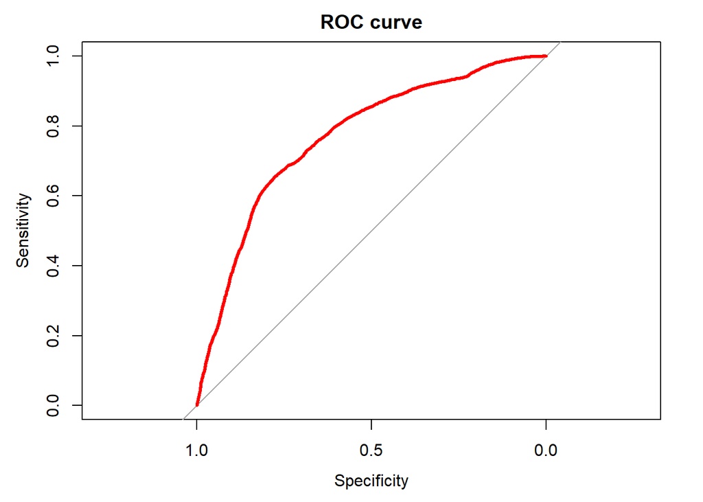

```r
nb_prob_pred <- predict(nb_tuned_best, newdata = train_dm_validate, type = 'raw')
roc_curve=roc(response=train_dm_validate$Disease, predictor= nb_prob_pred[,'2'])
plot(roc_curve, col="red", lwd=3, main="ROC curve")
```

```r
auc(roc_curve)
```

```
## Area under the curve: 0.7677
```

### **c] Random Forest**

##### Running the baseline model of Random Forest for training dataset.

##### Random forest is made of multiple decision trees. Unlike boosting methods, it has **fixed probability distribution**. mtry features are randomly selected for each decision tree. **Generalisation error** is directly proportional to the *__correlation_* between decision trees but the inversely proportional to the **strength** of the tree. Hence, we have to select the best possible number for mtry, which we will do in the next model.

```r
#model_rf <- train(Disease ~ ., data = train_dm_train, method = "rf")
model_rf
```

```
## Random Forest
##
## 35436 samples
##    19 predictor
##     2 classes: '1', '2'
##
## No pre-processing
## Resampling: Bootstrapped (25 reps)
## Summary of sample sizes: 35436, 35436, 35436, 35436, 35436, 35436, ...
## Resampling results across tuning parameters:
##
##   mtry  Accuracy   Kappa
##    2    0.7283490  0.4578353
##   10    0.6997548  0.3996286
##   19    0.6822591  0.3641403
##
## Accuracy was used to select the optimal model using the largest value.
## The final value used for the model was mtry = 2.
```

##### **Now running the random forest model by tuning it for hyperparameters. Here hyperparameters include:**

##### 1] “.mtry”: that means number of columns selected randomly for each decision tree in random forest. Ideally, to calculate mtry this formula is used:

##### **mtry = [log_to_the_base(ncol) + 1]** After running, multiple models it was found that this is giving more generalisation error, hence reduced to other best number.

##### 2] “ntree”: Number of trees in random forest.

##### Note that here we are not using any hyperparameters for pruning decision tree. The reason for that is every tree in random forest has very limited number of columns. So, tree length is very short. Hence, trees in random forest are **preferred to grow to the full length** as that will **reduce the bias** in our predictions. ntree parameter cannot be specified in a grid and hence we will use **for loop** to run through multiple ntree values.

```r
#mt <- round(sqrt(ncol(train_dm_train)))
#control <- trainControl(method="repeatedcv", number=3, repeats=3)
#tunegrid <- expand.grid(.mtry=c((mt-2):(mt)))

#rf_models <- list()
#for (ntree in c(350, 400, 500)) {
#   set.seed(73)
#   rf_tuned <- train(Disease~., data=train_dm_train, method="rf", #metric="Accuracy",tuneGrid=tunegrid,
#                trControl=control, ntree=ntree, verbose = TRUE)
#   num_trees <- toString(ntree)
#   rf_models[[num_trees]] <- rf_tuned
#}
```

```r
Accuracy_results <- summary(results)$statistics$Accuracy
best_model_Index <- ceiling(which.max(Accuracy_results)/ncol(Accuracy_results))
rf_tuned_best <- rf_models[best_model_Index][[1]]
rf_tuned_best
```

```
## Random Forest
##
## 35436 samples
##    19 predictor
##     2 classes: '1', '2'
##
## No pre-processing
## Resampling: Cross-Validated (3 fold, repeated 3 times)
## Summary of sample sizes: 23624, 23624, 23624, 23624, 23624, 23624, ...
## Resampling results across tuning parameters:
##
##   mtry  Accuracy   Kappa
##   2     0.7277627  0.4566858
##   3     0.7319111  0.4647523
##   4     0.7322967  0.4651774
##
## Accuracy was used to select the optimal model using the largest value.
## The final value used for the model was mtry = 4.
```

##### dotplot generated for all the models of random forest for comparison

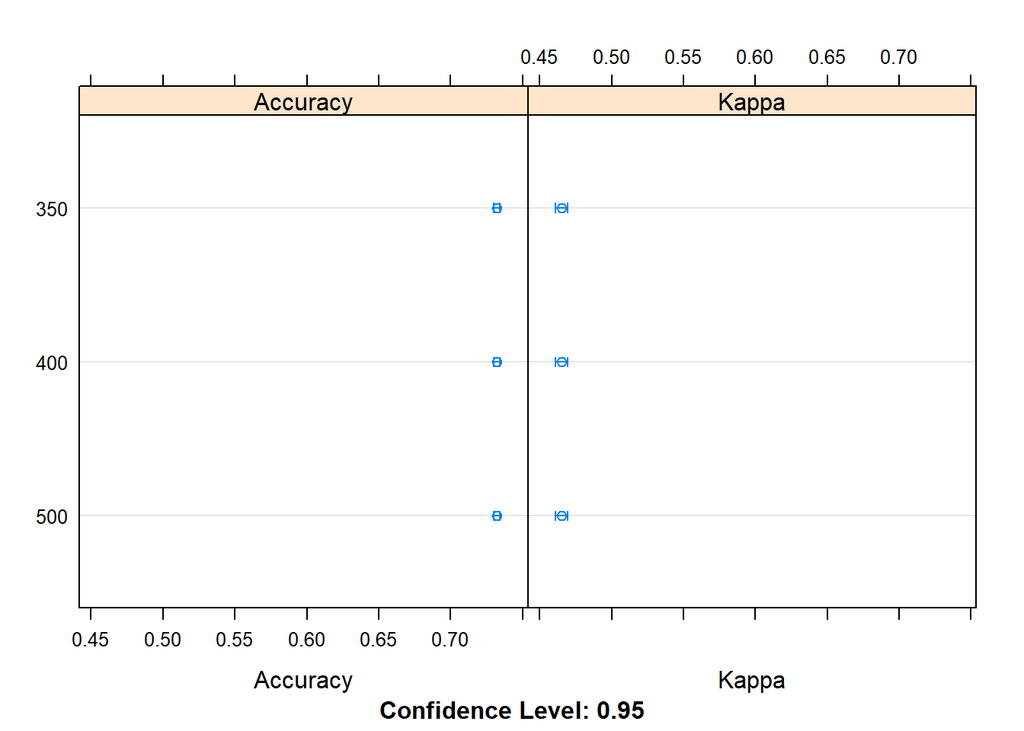

```r
dotplot(results)
```

##### Now, predicting the values for validation dataset. Then using the predictions to plot confusion matrix. Evaluating the parameters such as accuracy and recall.

```r
rf_tuned_predict <- predict(rf_tuned_best, newdata = train_dm_validate)
confusionMatrix(rf_tuned_predict, train_dm_validate$Disease)
```

```
## Confusion Matrix and Statistics
##
##           Reference
## Prediction    1    2
##          1 4455 1880
##          2 1338 4139
##
##                Accuracy : 0.7276
##                  95% CI : (0.7194, 0.7356)
##     No Information Rate : 0.5096
##     P-Value [Acc > NIR] : < 2.2e-16
##
##                   Kappa : 0.4559
##
##  Mcnemar's Test P-Value : < 2.2e-16
##
##             Sensitivity : 0.7690
##             Specificity : 0.6877
##          Pos Pred Value : 0.7032
##          Neg Pred Value : 0.7557
##              Prevalence : 0.4904
##          Detection Rate : 0.3772
##    Detection Prevalence : 0.5363
##       Balanced Accuracy : 0.7283
##
##        'Positive' Class : 1
##
```

##### Plotting the ROC curve for predicted classes of an observation and Calculating he area under that curve (AUC)

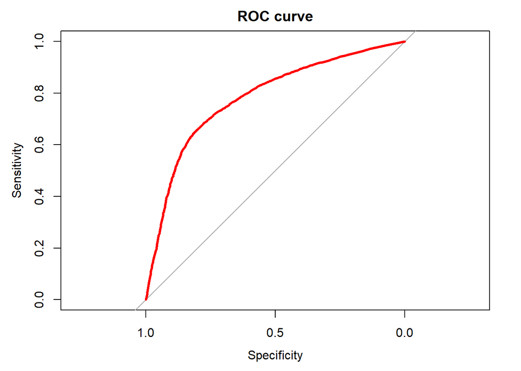

```
## [[1]]
##
## Call:
## roc.default(response = train_dm_validate$Disease, predictor = roc_prob_pred$`1`)
##
## Data: roc_prob_pred$`1` in 5793 controls (train_dm_validate$Disease 1) > 6019 cases (train_dm_validate$Disease 2).
## Area under the curve: 0.7815
##
## [[2]]
## Area under the curve: 0.7815
```

```r
ROC_AUC(rf_tuned_best)
```

##### Checking the variable importance for the random forest model built by tuning the hyperparameters: Important observation:

##### 1.**High blood pressure** were highly correlated variables as we saw in the correlation plot. Here we can see that both the variables have very high importance.

##### 2.Newly created variables such as **BMI** and **BP_Category** are helping a lot in model building and prediction.

```r
varImp(rf_tuned)
```

```
## rf variable importance
##
##                           Overall
## High.Blood.Pressure      100.0000
## BMI                       62.8675
## Age                       56.6369
## Low.Blood.Pressure        40.2366
## BP_Category_HT_stage2     40.1053
## BP_Category_Normal        12.9863
## `Cholesterol_too high`    11.1270
## BP_Category_HT_stage1      9.0714
## Cholesterol_normal         8.4952
## Exercise                   3.7808
## Smoke                      1.9598
## Glucose_normal             1.1866
## Alcohol                    1.1053
## Gender_female              0.8566
## Cholesterol_high           0.8022
## Gender_male                0.7682
## BP_Category_Hypertensive   0.2953
## `Glucose_too high`         0.1355
## Glucose_high               0.0000
```

### **Support Vector Machines**

### **d] Support Vector Machines - Linear Base Model**

##### SVM linear model is a **maximum margin classifier** model. Given that a binary classification data can be classified with multiple decision boundries, SVM linear tries to find a boundary with the margin. So, unlike other classifiers SVM needs more than just a decision boundary so that it can reduce the **generalisation error** on the testing datatset.

```r
#set.seed(73)
#svm_lin_base <- train(Disease ~ ., data = train_dm_train,
#                          method = "svmLinear")
print(svm_lin_base)
```

```
## Support Vector Machines with Linear Kernel
##
## 35436 samples
##    19 predictor
##     2 classes: '1', '2'
##
## No pre-processing
## Resampling: Bootstrapped (25 reps)
## Summary of sample sizes: 35436, 35436, 35436, 35436, 35436, 35436, ...
## Resampling results:
##
##   Accuracy   Kappa
##   0.7186027  0.4391228
##
## Tuning parameter 'C' was held constant at a value of 1
```

##### Now, predicting the values for validation dataset. Then using the predictions to plot confusion matrix. Evaluating the parameters such as accuracy and recall.

## **Recall has crossed the value of 80%**

```r
svm_lin_base_predict <- predict(svm_lin_base, newdata = train_dm_validate)
confusionMatrix(svm_lin_base_predict, train_dm_validate$Disease)
```

```
## Confusion Matrix and Statistics
##
##           Reference
## Prediction    1    2
##          1 4650 2252
##          2 1143 3767
##
##                Accuracy : 0.7126
##                  95% CI : (0.7043, 0.7207)
##     No Information Rate : 0.5096
##     P-Value [Acc > NIR] : < 2.2e-16
##
##                   Kappa : 0.427
##
##  Mcnemar's Test P-Value : < 2.2e-16
##
##             Sensitivity : 0.8027
##             Specificity : 0.6259
##          Pos Pred Value : 0.6737
##          Neg Pred Value : 0.7672
##              Prevalence : 0.4904
##          Detection Rate : 0.3937
##    Detection Prevalence : 0.5843
##       Balanced Accuracy : 0.7143
##
##        'Positive' Class : 1
##
```

### **e] Support Vector Machines - Linear Tuned Model**

##### Tuning the linear base SVM model with hyperparameters. The hyperparameter we will be using here ‘C’: ‘C’ is also known as cost. Linear SVM can have **soft margin** which means it can have flexible decision boundary. It can be done by adding **slack variable** to the minimize function while creating the boundary. To **compensate for the slack variable** we have to add this **‘C’** parameter to the cost function. ‘C’ allows the misclassification of some points so we might get boundary with large margin and help in reducing the generalization error. Higher ‘C’ value might result in **overfitting**.

```r
#set.seed(73)
#svm_lin_tuned <- train(make.names(Disease) ~ ., data = train_dm_train, method = "svmLinear",
#                 trControl = trainControl(method="repeatedcv", number=3, repeats=3), tuneGrid =                  expand.grid(C = seq(0.5, 0.7, 0.05)), metric="Accuracy")
print(svm_lin_tuned)
```

```
## Support Vector Machines with Linear Kernel
##
## 35436 samples
##    19 predictor
##     2 classes: 'X1', 'X2'
##
## No pre-processing
## Resampling: Cross-Validated (3 fold, repeated 3 times)
## Summary of sample sizes: 23624, 23624, 23624, 23624, 23624, 23624, ...
## Resampling results across tuning parameters:
##
##   C     Accuracy   Kappa
##   0.50  0.7189299  0.4395905
##   0.55  0.7189299  0.4395905
##   0.60  0.7189299  0.4395905
##   0.65  0.7189299  0.4395905
##   0.70  0.7189299  0.4395905
##
## Accuracy was used to select the optimal model using the largest value.
## The final value used for the model was C = 0.5.
```

##### Plotting the curve for different values of C against the accuracy

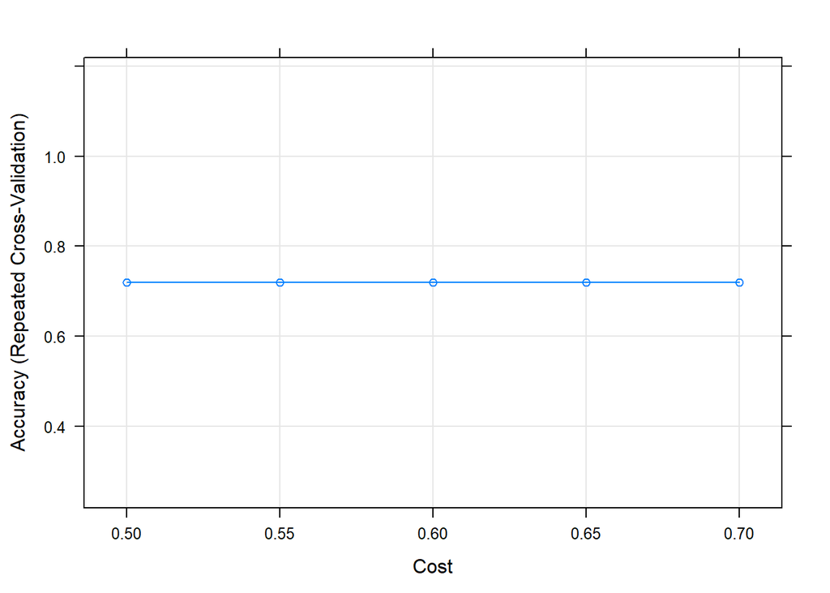

```r
plot(svm_lin_tuned)
```

##### Now, predicting the values for validation dataset. Then using the predictions to plot confusion matrix. Evaluating the parameters such as accuracy and recall.

## **Reducing type 2 error: we have recall > 80%**

```r
svm_lin_tuned_predict <- predict(svm_lin_tuned, newdata = train_dm_validate)
confusionMatrix(svm_lin_tuned_predict, as.factor(make.names(train_dm_validate$Disease)))
```

```
## Confusion Matrix and Statistics
##
##           Reference
## Prediction   X1   X2
##         X1 4650 2252
##         X2 1143 3767
##
##                Accuracy : 0.7126
##                  95% CI : (0.7043, 0.7207)
##     No Information Rate : 0.5096
##     P-Value [Acc > NIR] : < 2.2e-16
##
##                   Kappa : 0.427
##
##  Mcnemar's Test P-Value : < 2.2e-16
##
##             Sensitivity : 0.8027
##             Specificity : 0.6259
##          Pos Pred Value : 0.6737
##          Neg Pred Value : 0.7672
##              Prevalence : 0.4904
##          Detection Rate : 0.3937
##    Detection Prevalence : 0.5843
##       Balanced Accuracy : 0.7143
##
##        'Positive' Class : X1
##
```

### SVM NonLinear Base

##### Non-linear function helps in classification when a linear decision boundary is not able to classify the dataset. Mathematically, we should project the data into **higher dimensions** and use the same linear boundary (hyperplane) to seperate the classes. These **calculations become very complicated** especially for higher dimension. Hence, SVM uses **kernel trick** i.e. nothing but finding and applying a function that can perform the same calculations (measuring the similarity) in lower dimension only and hence **reducing the computation time**.

```r
#svm_nl_base <- train(Disease ~ ., data = train_dm_train, method = "svmRadial")
print(svm_nl_base)
```

```
## Support Vector Machines with Radial Basis Function Kernel
##
## 35436 samples
##    19 predictor
##     2 classes: '1', '2'
##
## No pre-processing
## Resampling: Bootstrapped (25 reps)
## Summary of sample sizes: 35436, 35436, 35436, 35436, 35436, 35436, ...
## Resampling results across tuning parameters:
##
##   C     Accuracy   Kappa
##   0.25  0.7225089  0.4464048
##   0.50  0.7243728  0.4499607
##   1.00  0.7260976  0.4532835
##
## Tuning parameter 'sigma' was held constant at a value of 0.04974525
## Accuracy was used to select the optimal model using the largest value.
## The final values used for the model were sigma = 0.04974525 and C = 1.
```

##### Now, predicting the values for validation dataset. Then using the predictions to plot confusion matrix. Evaluating the parameters such as accuracy and recall.

```r
svm_nl_base_predict <- predict(svm_nl_base, newdata = train_dm_validate)
confusionMatrix(svm_nl_base_predict, train_dm_validate$Disease)
```

```
## Confusion Matrix and Statistics
##
##           Reference
## Prediction    1    2
##          1 4554 2036
##          2 1239 3983
##
##                Accuracy : 0.7227
##                  95% CI : (0.7146, 0.7308)
##     No Information Rate : 0.5096
##     P-Value [Acc > NIR] : < 2.2e-16
##
##                   Kappa : 0.4467
##
##  Mcnemar's Test P-Value : < 2.2e-16
##
##             Sensitivity : 0.7861
##             Specificity : 0.6617
##          Pos Pred Value : 0.6910
##          Neg Pred Value : 0.7627
##              Prevalence : 0.4904
##          Detection Rate : 0.3855
##    Detection Prevalence : 0.5579
##       Balanced Accuracy : 0.7239
##
##        'Positive' Class : 1
##
```

### SVM NonLinear Tuned

##### Non Linear SVM uses “svmRadial” function instead linear function for the calculation of the **similarity between landmarks and any given point**. For SVM, every other point is the landmark with respected to the given point. The similarity (distance) with every other observation is calculated for every observation. For this calculation svmRadial function is used. The hyperparameters we are providing are nothing but **‘C’** cost parameter same as before and **‘Sigma’** which is a parameter of radial function. Radial function is similar to **‘Guassian’ distribution** where:

##### **lambda = 1/(2(sigma-squared))** where lambda is a gaussian parameter

```r
#svm_nl_tuned <- train(Disease ~ ., data = train_dm_train,
#                       tuneGrid = expand.grid(sigma = seq(0.1, 0.3, 0.1), C = seq(0.5, 1.5, #0.5)),
#                       method = "svmRadial", trControl = trainControl(method = "repeatedcv",
#                       number = 3, repeats = 3))

print(svm_nl_tuned)
```

```
## Support Vector Machines with Radial Basis Function Kernel
##
## 35436 samples
##    19 predictor
##     2 classes: '1', '2'
##
## No pre-processing
## Resampling: Cross-Validated (3 fold, repeated 3 times)
## Summary of sample sizes: 23624, 23624, 23624, 23624, 23624, 23624, ...
## Resampling results across tuning parameters:
##
##   sigma  C    Accuracy   Kappa
##   0.1    0.5  0.7277627  0.4565057
##   0.1    1.0  0.7284024  0.4577706
##   0.1    1.5  0.7283836  0.4577303
##   0.2    0.5  0.7274617  0.4556037
##   0.2    1.0  0.7277063  0.4561601
##   0.2    1.5  0.7268033  0.4543739
##   0.3    0.5  0.7269444  0.4543383
##   0.3    1.0  0.7263611  0.4533174
##   0.3    1.5  0.7254863  0.4515999
##
## Accuracy was used to select the optimal model using the largest value.
## The final values used for the model were sigma = 0.1 and C = 1.
```

##### Plotting the graph for svm_nl_tuned model

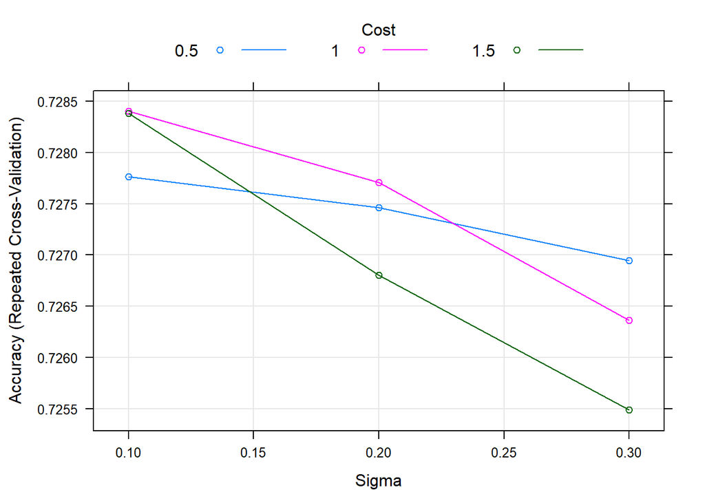

```r
plot(svm_nl_tuned)
```

##### Now, predicting the values for validation dataset. Then using the predictions to plot confusion matrix. Evaluating the parameters such as accuracy and recall.

```r
svm_nl_tuned_predict <- predict(svm_nl_tuned, newdata = train_dm_validate)
confusionMatrix(svm_nl_tuned_predict, train_dm_validate$Disease)
```

```
## Confusion Matrix and Statistics
##
##           Reference
## Prediction    1    2
##          1 4520 1975
##          2 1273 4044
##
##                Accuracy : 0.725
##                  95% CI : (0.7169, 0.7331)
##     No Information Rate : 0.5096
##     P-Value [Acc > NIR] : < 2.2e-16
##
##                   Kappa : 0.4511
##
##  Mcnemar's Test P-Value : < 2.2e-16
##
##             Sensitivity : 0.7803
##             Specificity : 0.6719
##          Pos Pred Value : 0.6959
##          Neg Pred Value : 0.7606
##              Prevalence : 0.4904
##          Detection Rate : 0.3827
##    Detection Prevalence : 0.5499
##       Balanced Accuracy : 0.7261
##
##        'Positive' Class : 1
##
```

### **f] Gradient Boosting Machine**

##### **Gradient Boosting Machine - Base Model**

##### Just like random forest GBM model also works with multiple decision trees. Only diffrence is that in random forest all the trees run in parallel. **In GBM, trees run in series**. After every iterations the **weights** for the samples (observations) are updated. The samples which were misclassified are given more weights that the one which were classified correctly. Adding to that **boosting works on sampling with replacement**. The samples which were not selected in the first iterations will also be given **higher weights** in next iterations. In this way the model progresses and helps us in **reducing the bias**.

```r
#gbm_base <- train(Disease ~ ., data = train_dm_train, method = "gbm")
print(gbm_base)
```

```
## Stochastic Gradient Boosting
##
## 35436 samples
##    19 predictor
##     2 classes: '1', '2'
##
## No pre-processing
## Resampling: Bootstrapped (25 reps)
## Summary of sample sizes: 35436, 35436, 35436, 35436, 35436, 35436, ...
## Resampling results across tuning parameters:
##
##   interaction.depth  n.trees  Accuracy   Kappa
##   1                   50      0.7232643  0.4479766
##   1                  100      0.7278530  0.4569625
##   1                  150      0.7297118  0.4605780
##   2                   50      0.7297055  0.4603366
##   2                  100      0.7330724  0.4668210
##   2                  150      0.7337316  0.4680528
##   3                   50      0.7325159  0.4655564
##   3                  100      0.7342540  0.4689124
##   3                  150      0.7344902  0.4693483
##
## Tuning parameter 'shrinkage' was held constant at a value of 0.1
##
## Tuning parameter 'n.minobsinnode' was held constant at a value of 10
## Accuracy was used to select the optimal model using the largest value.
## The final values used for the model were n.trees = 150,
##  interaction.depth = 3, shrinkage = 0.1 and n.minobsinnode = 10.
```

##### Plotting the graph for gbm_base model

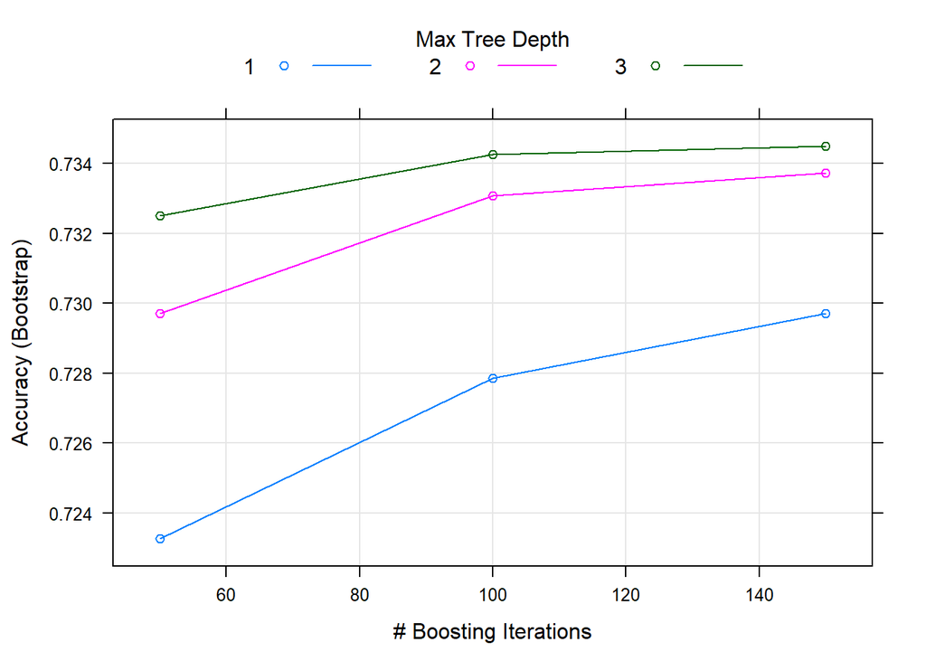

```r
plot(gbm_base)
```

##### Now, predicting the values for validation dataset. Then using the predictions to plot confusion matrix. Evaluating the parameters such as accuracy and recall.

```r
gbm_base_predict <- predict(gbm_base, newdata = train_dm_validate)
confusionMatrix(gbm_base_predict, train_dm_validate$Disease)
```

```
## Confusion Matrix and Statistics
##
##           Reference
## Prediction    1    2
##          1 4396 1764
##          2 1397 4255
##
##                Accuracy : 0.7324
##                  95% CI : (0.7243, 0.7404)
##     No Information Rate : 0.5096
##     P-Value [Acc > NIR] : < 2.2e-16
##
##                   Kappa : 0.4652
##
##  Mcnemar's Test P-Value : 7.524e-11
##
##             Sensitivity : 0.7588
##             Specificity : 0.7069
##          Pos Pred Value : 0.7136
##          Neg Pred Value : 0.7528
##              Prevalence : 0.4904
##          Detection Rate : 0.3722
##    Detection Prevalence : 0.5215
##       Balanced Accuracy : 0.7329
##
##        'Positive' Class : 1
##
```

### **GBM Tuned**

##### Now tuning the hyperparameters, we will be tuning model as a whole and individual trees as well:

##### 1]**interaction.depth**: this parameter specifies that how many splits we will perform on every decision tree in so that we will get the specified number of nodes in a decision tree. It is the maximum number of nodes in a decision tree. The value “6” is generally considered to be best for giving significant results.

##### 2] **n.tree**: This value tells the model how many decision trees to include in our entire model.

##### 3] **shrinkage**: This parameter defined the learning rate of gbm model. Just like L1 regularisations helps in reducing the unimportant features in regression, shrinkage parameter in gbm helps reduce the importance of useless decision trees. It reduced the speed of the model. “0.01” values is preferred for any datasets having 10,000+ observations.

##### 4] **n.minobsinnode**: minimum number of observations in the leaf nodes of the decision trees. 10 is considered to be good and big enough number. It should be less for smaller data with respect to rows.

```r
#tuneGrid_gbm <- expand.grid(interaction.depth=c(4,6,8), n.trees = c(400,500,600),
#                   shrinkage=c(0.01), n.minobsinnode=c(10))

#trainControl_gbm <- trainControl(method="cv", number=3)
#set.seed(28)
#gbm_tuned <- train(Disease ~ ., data = train_dm_train,
#                       tuneGrid = expand.grid(tuneGrid_gbm), method = "gbm",
#                       trControl = trainControl_gbm, verbose=FALSE, metric="Accuracy")
print(gbm_tuned)
```

```
## Stochastic Gradient Boosting
##
## 35436 samples
##    19 predictor
##     2 classes: '1', '2'
##
## No pre-processing
## Resampling: Cross-Validated (3 fold)
## Summary of sample sizes: 23624, 23624, 23624
## Resampling results across tuning parameters:
##
##   interaction.depth  n.trees  Accuracy   Kappa
##   4                  400      0.7332656  0.4669237
##   4                  500      0.7337453  0.4678287
##   4                  600      0.7345073  0.4693371
##   6                  400      0.7345355  0.4694349
##   6                  500      0.7354385  0.4712135
##   6                  600      0.7360312  0.4723851
##   8                  400      0.7352128  0.4708225
##   8                  500      0.7354103  0.4712010
##   8                  600      0.7357207  0.4717881
##
## Tuning parameter 'shrinkage' was held constant at a value of 0.01
##
## Tuning parameter 'n.minobsinnode' was held constant at a value of 10
## Accuracy was used to select the optimal model using the largest value.
## The final values used for the model were n.trees = 600,
##  interaction.depth = 6, shrinkage = 0.01 and n.minobsinnode = 10.
```

##### Plotting the graph for gbm_tuned model. Accuracy increases with increase innumber of trees but considering the generalisation error we are limiting the ntree to 600.

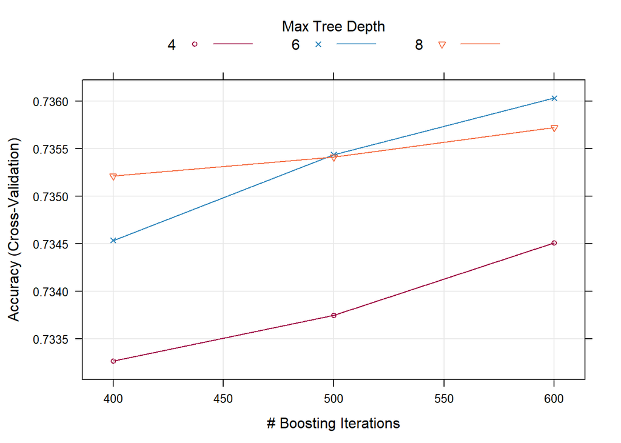

```r
trellis.par.set(caretTheme())
plot(gbm_tuned)
```

##### Now, predicting the values for validation dataset. Then using the predictions to plot confusion matrix. Evaluating the parameters such as accuracy and recall.

```r
gbm_tuned_predict <- predict(gbm_tuned, newdata = train_dm_validate)
confusionMatrix(gbm_tuned_predict, train_dm_validate$Disease)
```

```
## Confusion Matrix and Statistics
##
##           Reference
## Prediction    1    2
##          1 4386 1747
##          2 1407 4272
##
##                Accuracy : 0.733
##                  95% CI : (0.7249, 0.7409)
##     No Information Rate : 0.5096
##     P-Value [Acc > NIR] : < 2.2e-16
##
##                   Kappa : 0.4664
##
##  Mcnemar's Test P-Value : 1.577e-09
##
##             Sensitivity : 0.7571
##             Specificity : 0.7098
##          Pos Pred Value : 0.7151
##          Neg Pred Value : 0.7522
##              Prevalence : 0.4904
##          Detection Rate : 0.3713
##    Detection Prevalence : 0.5192
##       Balanced Accuracy : 0.7334
##
##        'Positive' Class : 1
##
```

##### Plotting the ROC curve for predicted classes of an observation and Calculating he area under that curve (AUC)

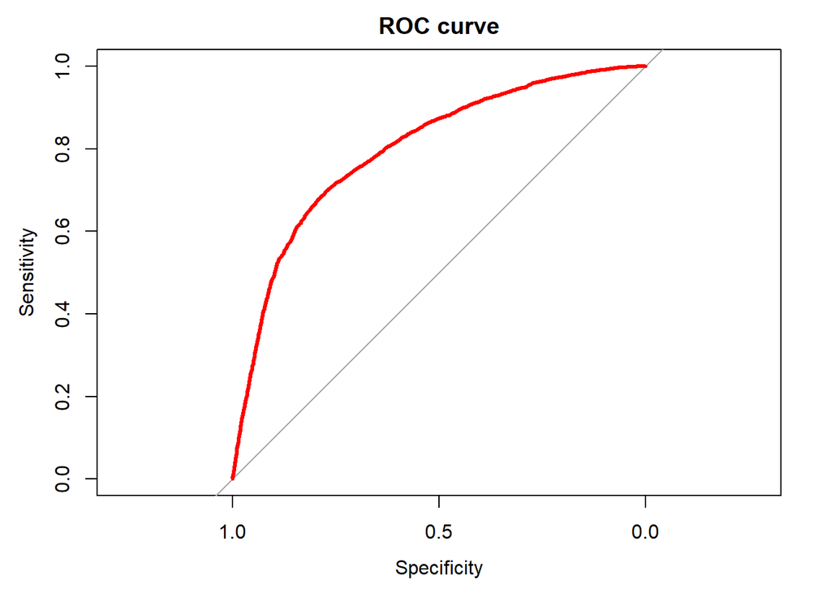

```
## [[1]]
##
## Call:
## roc.default(response = train_dm_validate$Disease, predictor = roc_prob_pred$`1`)
##
## Data: roc_prob_pred$`1` in 5793 controls (train_dm_validate$Disease 1) > 6019 cases (train_dm_validate$Disease 2).
## Area under the curve: 0.798
##
## [[2]]
## Area under the curve: 0.798
```

```r
ROC_AUC(gbm_tuned)
```

### Model Comparison

##### Both Accuracy and Kappa values suggests that **Gradient boosting** is the best algorithm (accuracy) for this problem

```r
model_comparison <- resamples(list(KNN_C = knn_base, RF = model_rf, SVML_C = svm_lin_base, SVMNL_C = svm_nl_base, GBM_C = gbm_base))
summary(model_comparison)
```

```
##
## Call:
## summary.resamples(object = model_comparison)
##
## Models: KNN_C, RF, SVML_C, SVMNL_C, GBM_C
## Number of resamples: 25
##
## Accuracy
##              Min.   1st Qu.    Median      Mean   3rd Qu.      Max. NA's
## KNN_C   0.6822202 0.6888059 0.6899824 0.6910581 0.6939836 0.6987952    0
## RF      0.7219374 0.7257059 0.7282801 0.7283490 0.7301149 0.7337958    0
## SVML_C  0.7114896 0.7151515 0.7190045 0.7186027 0.7212675 0.7255878    0
## SVMNL_C 0.7164771 0.7248564 0.7261341 0.7260976 0.7278491 0.7367976    0
## GBM_C   0.7272727 0.7318508 0.7351206 0.7344902 0.7361559 0.7422018    0
##
## Kappa
##              Min.   1st Qu.    Median      Mean   3rd Qu.      Max. NA's
## KNN_C   0.3642141 0.3774235 0.3798159 0.3819452 0.3874296 0.3975117    0
## RF      0.4460244 0.4527744 0.4574829 0.4578353 0.4612254 0.4685933    0
## SVML_C  0.4252434 0.4333202 0.4402903 0.4391228 0.4445027 0.4529272    0
## SVMNL_C 0.4337110 0.4506186 0.4536146 0.4532835 0.4568368 0.4741017    0
## GBM_C   0.4547825 0.4642518 0.4705279 0.4693483 0.4724603 0.4846583    0
```

## Conclusion:

##### Transforming test data with respect to the transformed train data to pass it through the various models make our final predictions

```r
test_df <- read.csv('Disease Prediction Testing.csv', stringsAsFactors = F)

#apply(is.na(test_df),2,sum)

#num_test_df <- test_df[sapply(test_df, is.numeric) | sapply(test_df, is.integer)]
#quantiles_test <- c(0.001, 0.002, 0.003, 0.985, 0.99, 0.999, 1)
#out_test_df <- data.frame(row.names = quantiles_test)
#for (i in 1:length(num_test_df)){
#  r <- as.vector(quantile(num_test_df[,i], quantiles_test))
#  out_test_df[,i] <- r
#}
#colnames(out_test_df) <- colnames(num_test_df)
#print(out_test_df)

test_df$Low.Blood.Pressure <- Out_Treat_W(test_df$Low.Blood.Pressure, 0.002, 0.985)
test_df$High.Blood.Pressure <- Out_Treat_W(test_df$High.Blood.Pressure, 0.003, 0.999)

for (i in 1:nrow(test_df)) {
  if (test_df$High.Blood.Pressure[i] >= 180 | test_df$Low.Blood.Pressure[i] >= 120) {
    test_df$BP_Category[i] = "Hypertensive"
  }
  else if (test_df$High.Blood.Pressure[i] >= 140 | test_df$Low.Blood.Pressure[i] >= 90) {
    test_df$BP_Category[i] = "HT_stage2"
  }
  else if (test_df$High.Blood.Pressure[i] >= 130 | test_df$Low.Blood.Pressure[i] >= 80) {
    test_df$BP_Category[i] = "HT_stage1"
  }
  else {
    test_df$BP_Category[i] = "Normal"
  }
}
for (i in 1:nrow(test_df)) {
  test_df$BMI[i] <- (test_df$Weight[i] / ((test_df$Height[i]/100)**2))
}
lr_drop_test <- c('Height', 'Weight')
test_df <- test_df[,-which(names(test_df) %in% lr_drop_test)]

scale_test <- c('Age', 'High.Blood.Pressure', 'Low.Blood.Pressure', 'BMI')
for(i in 1:length(colnames(test_df))){
  if(colnames(test_df)[i] %in% scale_test){
    test_df[,i] <- as.vector(scale(test_df[,i]))
  }
}

dummies_test <- c('Gender','Cholesterol','Glucose', 'BP_Category')
test_df <- dummy_cols(test_df, select_columns = dummies_test)
test_df <- test_df[,-which(names(test_df) %in% dummies_test)]


flip_test <- c('Exercise', 'Alcohol', 'Smoke')
for(i in 1:length(colnames(test_df))){
  if(colnames(test_df)[i] %in% flip_test){
    for (j in 1:nrow(test_df)) {
      if(test_df[j,i] == 0){
        test_df[j,i] <- 1
      }
      else{
        test_df[j,i] <- 2
      }
    }
  }
}

test_df$ID <- NULL
```

##### Now predicting if a person will get the disease or will he/she be safe using actual test data set. Combining all the predictions into a dataframe and exporting the dataframe to a csv file

```r
NBC <- predict(nb_tuned_best, newdata = test_df)
KNN <- predict(knn_acc, newdata = test_df)
SVM_Linear <- predict(svm_lin_tuned, newdata = test_df)
SVM_RBF <- predict(svm_nl_tuned, newdata = test_df)
RF <- predict(rf_tuned_best, newdata = test_df)
GBM <- predict(gbm_tuned, newdata = test_df)

HW3_CSV <- data.frame(NBC, KNN, SVM_Linear, SVM_RBF, RF, GBM)

i <- sapply(HW3_CSV, is.factor)
HW3_CSV[i] <- lapply(HW3_CSV[i], as.integer)

HW3_CSV$NBC <- HW3_CSV$NBC - 1
HW3_CSV$KNN <- HW3_CSV$KNN - 1
HW3_CSV$SVM_Linear <- HW3_CSV$SVM_Linear - 1
HW3_CSV$SVM_RBF <- HW3_CSV$SVM_RBF - 1
HW3_CSV$RF <- HW3_CSV$RF - 1
HW3_CSV$GBM <- HW3_CSV$GBM - 1

#str(HW3_CSV)
#View(HW3_CSV)

#write.csv(HW3_CSV,"Assignment3.csv", row.names = TRUE)
```